# Description

**General Introduction**

This project uses the data from [LendingClub](https://www.lendingclub.com/) website data which was collected by Kaggle user [Wendy Kan](https://www.kaggle.com/wendykan/lending-club-loan-data).

**Wikipedia Introduction**

- https://www.wikiwand.com/en/LendingClub

LendingClub is an American peer-to-peer lending company, headquartered in San Francisco, California. It was the first peer-to-peer lender to register its offerings as securities with the Securities and Exchange Commission (SEC), and to offer loan trading on a secondary market. LendingClub is the world's largest peer-to-peer lending platform. The company claims that \$15.98 billion in loans had been originated through its platform up to December 31, 2015.

LendingClub enables borrowers to create unsecured personal loans between 1,000 and 40,000. The standard loan period is three years. Investors can search and browse the loan listings on LendingClub website and select loans that they want to invest in based on the information supplied about the borrower, amount of loan, loan grade, and loan purpose. Investors make money from interest. LendingClub makes money by charging borrowers an origination fee and investors a service fee.

**Dataset Introduction**  
These files contain complete loan data for all loans issued through the 2007-2015, including the current loan status (Current, Late, Fully Paid, etc.) and latest payment information. The file containing loan data through the "present" contains complete loan data for all loans issued through the previous completed calendar quarter. Additional features include credit scores, number of finance inquiries, address including zip codes, and state, and collections among others. The file is a matrix of about 890 thousand observations and 75 variables. A data dictionary is provided in a separate file.

**NOTE** I am using 2007-2014 for training data and 2015 as test data.

# Imports

```python
%load_ext autoreload
```

```python
%autoreload 2
```

```python
# my personal library
from bhishan import bp
```

```python
import numpy as np
import pandas as pd
import seaborn as sns
pd.plotting.register_matplotlib_converters()

from tqdm import tqdm_notebook as tqdm
import matplotlib.pyplot as plt

%matplotlib inline
%config InlineBackend.figure_format = 'retina'
plt.style.use('ggplot')


[(x.__name__,x.__version__) for x in [np,pd,sns]]
```

```
[('numpy', '1.18.1'), ('pandas', '1.0.1'), ('seaborn', '0.9.0')]
```

```python
pd.options.display.max_columns=None
```

```python
%%javascript
IPython.OutputArea.auto_scroll_threshold = 9999;
```

```python
import sys # sys.getsizeof(df)
```

# Load the data

```python
!du -sh ../data/raw/loan_data_2007_2014.csv
```

```
229M	../data/raw/loan_data_2007_2014.csv
```

```python
# our data is small, we can use pandas instead of pyspark.
```

```python
!head -1 ../data/raw/loan_data_2007_2014.csv
```

[output not shown]

```python
ifile = '../data/raw/loan_data_2007_2014.csv'
tmp = pd.read_csv(ifile,nrows=5)

print(tmp.shape)
tmp
```

```
(5, 75)
```

|  | Unnamed: 0 | id | member_id | loan_amnt | funded_amnt | funded_amnt_inv | term | int_rate | installment | grade | sub_grade | emp_title | emp_length | home_ownership | annual_inc | verification_status | issue_d | loan_status | pymnt_plan | url | desc | purpose | title | zip_code | addr_state | dti | delinq_2yrs | earliest_cr_line | inq_last_6mths | … |
| --- | --- | --- | --- | --- | --- | --- | --- | --- | --- | --- | --- | --- | --- | --- | --- | --- | --- | --- | --- | --- | --- | --- | --- | --- | --- | --- | --- | --- | --- | --- |
| 0 | 0 | 1077501 | 1296599 | 5000 | 5000 | 4975.0 | 36 months | 10.65 | 162.87 | B | B2 | NaN | 10+ years | RENT | 24000.0 | Verified | Dec-11 | Fully Paid | n | https://www.lendingclub.com/browse/loanDetail.... | Borrower added on 12/22/11 > I need to upgra... | credit_card | Computer | 860xx | AZ | 27.65 | 0.0 | Jan-85 | 1.0 | … |
| 1 | 1 | 1077430 | 1314167 | 2500 | 2500 | 2500.0 | 60 months | 15.27 | 59.83 | C | C4 | Ryder | < 1 year | RENT | 30000.0 | Source Verified | Dec-11 | Charged Off | n | https://www.lendingclub.com/browse/loanDetail.... | Borrower added on 12/22/11 > I plan to use t... | car | bike | 309xx | GA | 1.00 | 0.0 | Apr-99 | 5.0 | … |
| 2 | 2 | 1077175 | 1313524 | 2400 | 2400 | 2400.0 | 36 months | 15.96 | 84.33 | C | C5 | NaN | 10+ years | RENT | 12252.0 | Not Verified | Dec-11 | Fully Paid | n | https://www.lendingclub.com/browse/loanDetail.... | NaN | small_business | real estate business | 606xx | IL | 8.72 | 0.0 | Nov-01 | 2.0 | … |
| 3 | 3 | 1076863 | 1277178 | 10000 | 10000 | 10000.0 | 36 months | 13.49 | 339.31 | C | C1 | AIR RESOURCES BOARD | 10+ years | RENT | 49200.0 | Source Verified | Dec-11 | Fully Paid | n | https://www.lendingclub.com/browse/loanDetail.... | Borrower added on 12/21/11 > to pay for prop... | other | personel | 917xx | CA | 20.00 | 0.0 | Feb-96 | 1.0 | … |
| 4 | 4 | 1075358 | 1311748 | 3000 | 3000 | 3000.0 | 60 months | 12.69 | 67.79 | B | B5 | University Medical Group | 1 year | RENT | 80000.0 | Source Verified | Dec-11 | Current | n | https://www.lendingclub.com/browse/loanDetail.... | Borrower added on 12/21/11 > I plan on combi... | other | Personal | 972xx | OR | 17.94 | 0.0 | Jan-96 | 0.0 | … |

```python
# for eda purpose, we dont need all columns.
# select only few features.

usecols = ['loan_amnt','funded_amnt','term',
          'int_rate','grade','emp_title',
           'emp_length', 'home_ownership', 'annual_inc',
           'issue_d', 'loan_status', 'pymnt_plan',
           'addr_state','dti','verification_status','purpose'
          ]

df = pd.read_csv(ifile,usecols=usecols)

df.head(2)
```

|  | loan_amnt | funded_amnt | term | int_rate | grade | emp_title | emp_length | home_ownership | annual_inc | verification_status | issue_d | loan_status | pymnt_plan | purpose | addr_state | dti |
| --- | --- | --- | --- | --- | --- | --- | --- | --- | --- | --- | --- | --- | --- | --- | --- | --- |
| 0 | 5000 | 5000 | 36 months | 10.65 | B | NaN | 10+ years | RENT | 24000.0 | Verified | Dec-11 | Fully Paid | n | credit_card | AZ | 27.65 |
| 1 | 2500 | 2500 | 60 months | 15.27 | C | Ryder | < 1 year | RENT | 30000.0 | Source Verified | Dec-11 | Charged Off | n | car | GA | 1.00 |

# Data Visualization

## Correlation heatmap

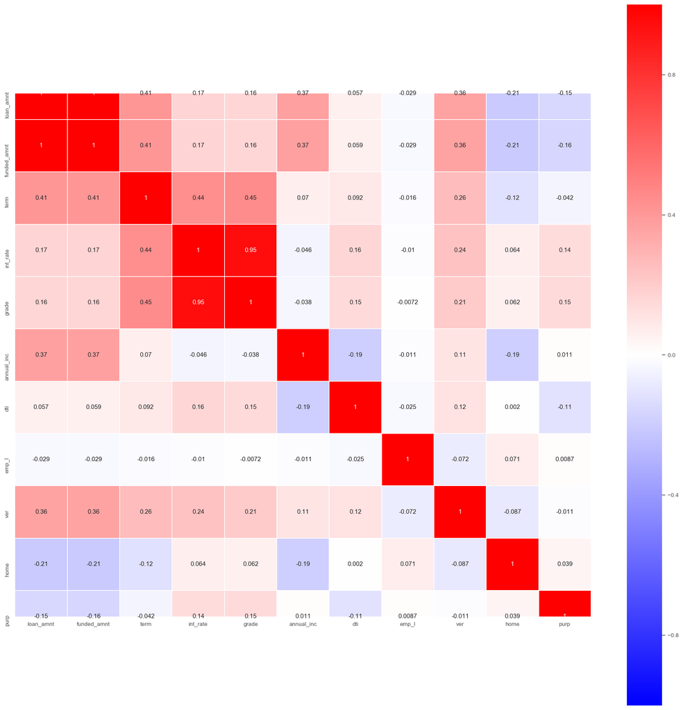

```python
plt.figure(figsize=(20,20))
sns.set_context("paper", font_scale=1)


sns.heatmap(df.assign(
    grade=df.grade.astype('category').cat.codes,
    term=df.term.astype('category').cat.codes,
    emp_l=df.emp_length.astype('category').cat.codes,
    ver =df.verification_status.astype('category').cat.codes,           home=df.home_ownership.astype('category').cat.codes,                 purp=df.purpose.astype('category').cat.codes
).corr(),
annot=True, cmap='bwr',vmin=-1,
            vmax=1, square=True,
            linewidths=0.5)
```

# Continuous Variables

```python
df.head(2)
```

|  | loan_amnt | funded_amnt | term | int_rate | grade | emp_title | emp_length | home_ownership | annual_inc | verification_status | issue_d | loan_status | pymnt_plan | purpose | addr_state | dti |
| --- | --- | --- | --- | --- | --- | --- | --- | --- | --- | --- | --- | --- | --- | --- | --- | --- |
| 0 | 5000 | 5000 | 36 months | 10.65 | B | NaN | 10+ years | RENT | 24000.0 | Verified | Dec-11 | Fully Paid | n | credit_card | AZ | 27.65 |
| 1 | 2500 | 2500 | 60 months | 15.27 | C | Ryder | < 1 year | RENT | 30000.0 | Source Verified | Dec-11 | Charged Off | n | car | GA | 1.00 |

|  | count | mean | std | min | 25% | 50% | 75% | max |
| --- | --- | --- | --- | --- | --- | --- | --- | --- |
| loan_amnt | 466285.0 | 14317.277577 | 8286.509164 | 500.0 | 8000.0 | 12000.0 | 20000.0 | 35000.0 |

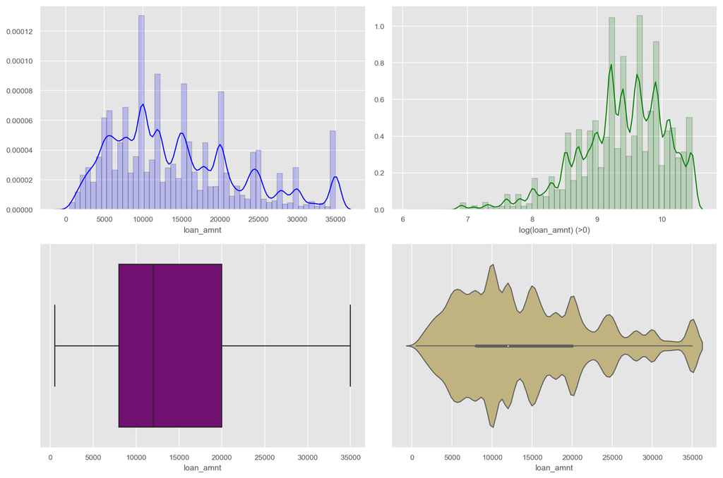

```python
bp.plot_num(df, 'loan_amnt')
```

|  | count | mean | std | min | 25% | 50% | 75% | max |
| --- | --- | --- | --- | --- | --- | --- | --- | --- |
| funded_amnt | 466285.0 | 14291.801044 | 8274.3713 | 500.0 | 8000.0 | 12000.0 | 20000.0 | 35000.0 |

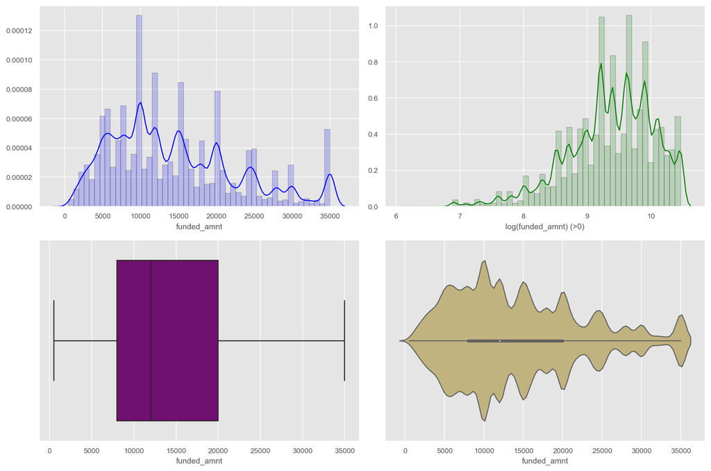

```python
bp.plot_num(df, 'funded_amnt')
```

|  | count | mean | std | min | 25% | 50% | 75% | max |
| --- | --- | --- | --- | --- | --- | --- | --- | --- |
| annual_inc | 466281.0 | 73277.38147 | 54963.568654 | 1896.0 | 45000.0 | 63000.0 | 88960.0 | 7500000.0 |

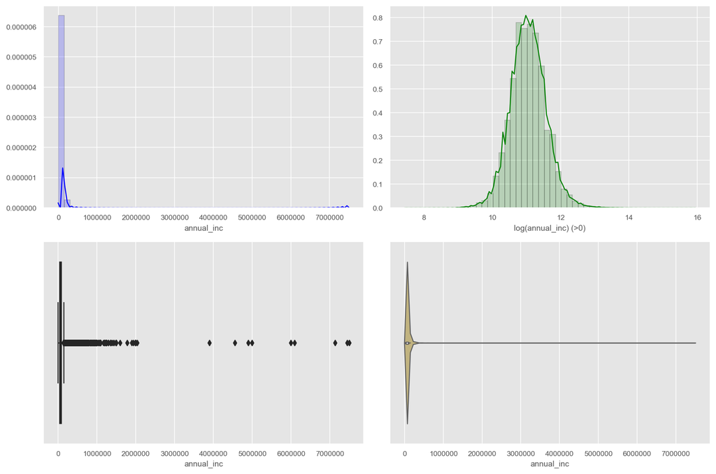

```python
bp.plot_num(df, 'annual_inc',xlim=[0,0.2e8])
```

|  | count | mean | std | min | 25% | 50% | 75% | max |
| --- | --- | --- | --- | --- | --- | --- | --- | --- |
| dti | 466285.0 | 17.218758 | 7.851121 | 0.0 | 11.36 | 16.87 | 22.78 | 39.99 |

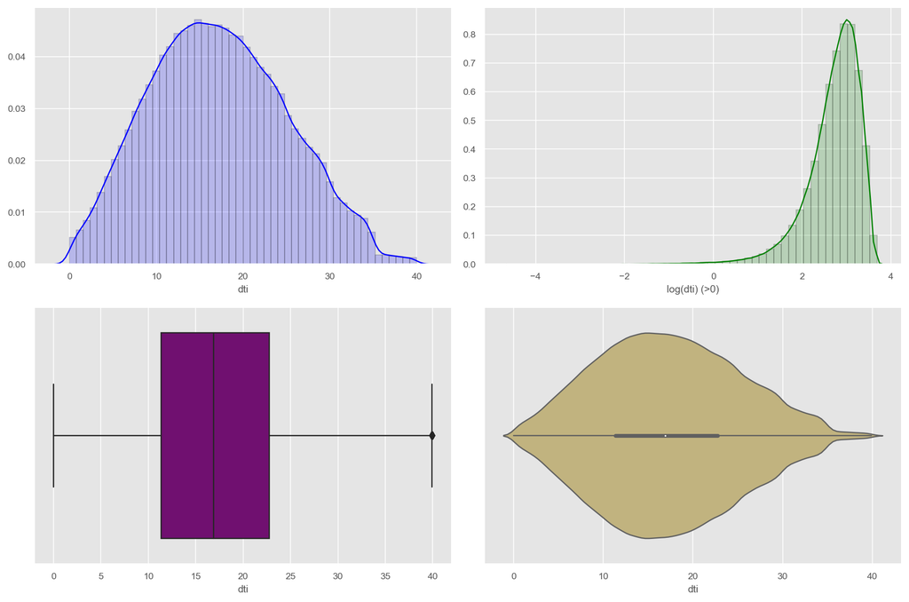

```python
bp.plot_num(df, 'dti')
```

# Categorical Variables

```python
df.select_dtypes('object').head(2)
```

|  | term | grade | emp_title | emp_length | home_ownership | verification_status | issue_d | loan_status | pymnt_plan | purpose | addr_state |
| --- | --- | --- | --- | --- | --- | --- | --- | --- | --- | --- | --- |
| 0 | 36 months | B | NaN | 10+ years | RENT | Verified | Dec-11 | Fully Paid | n | credit_card | AZ |
| 1 | 60 months | C | Ryder | < 1 year | RENT | Source Verified | Dec-11 | Charged Off | n | car | GA |

```python
df.select_dtypes('object').nunique().sort_values()
```

```
term                        2
pymnt_plan                  2
verification_status         3
home_ownership              6
grade                       7
loan_status                 9
emp_length                 11
purpose                    14
addr_state                 50
issue_d                    91
emp_title              205475
dtype: int64
```

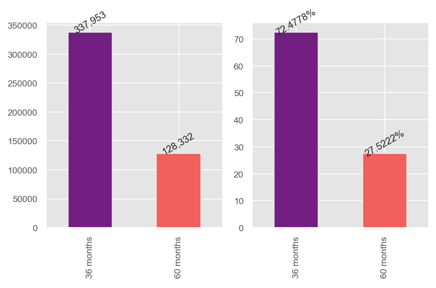

```
==================================================
Feature: **term**
Overall Count:
     36 months: 72.48%
     60 months: 27.52%
```

```python
bp.plot_cat(df,'term')
```

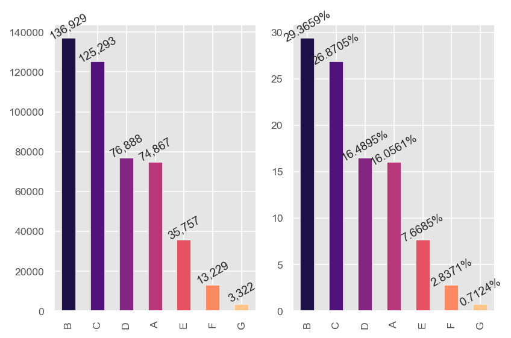

```
==================================================
Feature: **grade**
Overall Count:
    B: 29.37%
    C: 26.87%
    D: 16.49%
    A: 16.06%
    E: 7.67%
    F: 2.84%
    G: 0.71%
```

```python
bp.plot_cat(df, 'grade')
```

# Bi-variate Analysis

```python
df['loan_status'].unique()
```

```
array(['Fully Paid', 'Charged Off', 'Current', 'Default',
       'Late (31-120 days)', 'In Grace Period', 'Late (16-30 days)',
       'Does not meet the credit policy. Status:Fully Paid',
       'Does not meet the credit policy. Status:Charged Off'],
      dtype=object)
```

```python
bad = ['Late (31-120 days)',
       'Charged Off',
       'Default',
       'Does not meet the credit policy. Status:Charged Off']
df['good_bad'] = np.where(df['loan_status'].isin(bad),0,1)
```

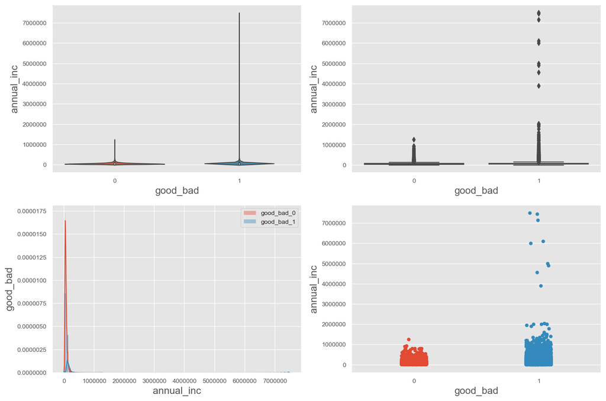

| good_bad | count | mean | std | min | 25% | 50% | 75% | max |
| --- | --- | --- | --- | --- | --- | --- | --- | --- |
| good_bad_0 | 50968.0 | 65453.94 | 41188.09 | 2000.0 | 40693.86 | 56300.0 | 79000.0 | 1250000.0 |
| good_bad_1 | 415313.0 | 74237.49 | 56348.16 | 1896.0 | 45000.00 | 64000.0 | 90000.0 | 7500000.0 |
| annual_inc | 466281.0 | 73277.38 | 54963.57 | 1896.0 | 45000.00 | 63000.0 | 88960.0 | 7500000.0 |

```python
bp.plot_num_cat(df,'annual_inc','good_bad')
```

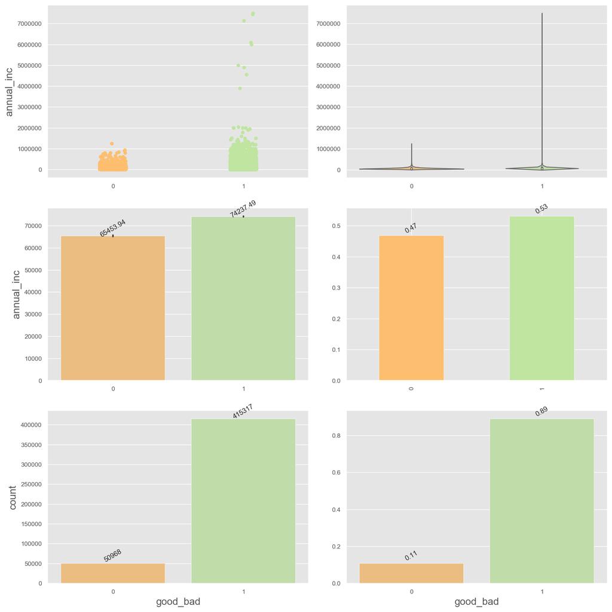

```python
bp.plot_cat_num(df,'good_bad','annual_inc')
```

# Map Visualization

```python
df.head(1)
```

|  | loan_amnt | funded_amnt | term | int_rate | grade | emp_title | emp_length | home_ownership | annual_inc | verification_status | issue_d | loan_status | pymnt_plan | purpose | addr_state | dti | good_bad |
| --- | --- | --- | --- | --- | --- | --- | --- | --- | --- | --- | --- | --- | --- | --- | --- | --- | --- |
| 0 | 5000 | 5000 | 36 months | 10.65 | B | NaN | 10+ years | RENT | 24000.0 | Verified | Dec-11 | Fully Paid | n | credit_card | AZ | 27.65 | 1 |

```python
df1 = df.groupby('addr_state')['good_bad'].sum().sort_values().reset_index()
df1.head(2)
```

|  | addr_state | good_bad |
| --- | --- | --- |
| 0 | ME | 4 |
| 1 | NE | 6 |

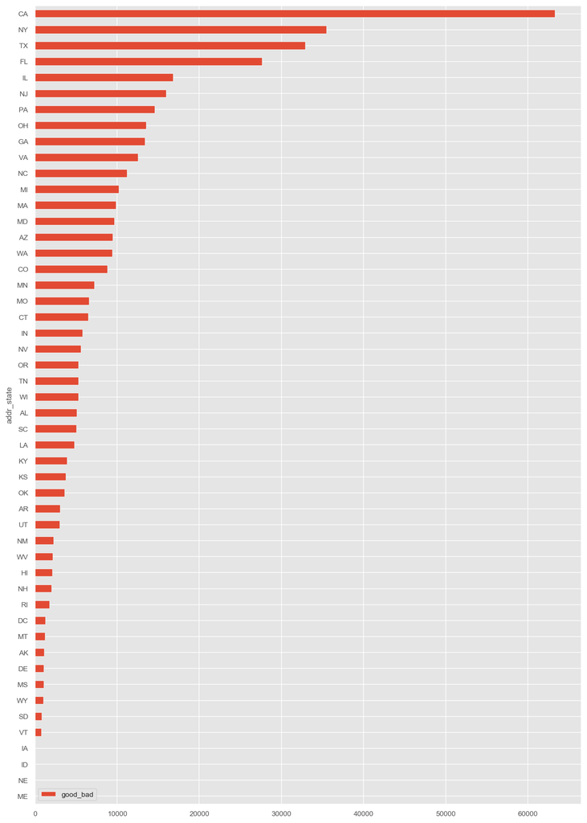

```python
df1.plot.barh(x='addr_state',y='good_bad',figsize=(12,18))
```

```python
[i for i in dir(bp) if 'map' in i]
```

```
['get_mapbox_access_token',
 'map_plot_bokeh',
 'plotly_corr_heatmap',
 'plotly_mapbox',
 'plotly_usa_bubble_map',
 'plotly_usa_map',
 'plotly_usa_map2']
```

```python
# help(bp.plotly_usa_map)
```

[output not shown]

```python
bp.plotly_usa_map(df1,'addr_state','good_bad',colorscale='RdBu',
                 title='Number of good borrowers per State')
```

[interactive chart not shown]